# team

Tyler Kruzan & Sai Gugulothu

2/10/2019

## Lab 2 - Team Collaboration

# Question 1: What is the overall number of chocolate bars rated?

```
##      Company Specific.Bean.Origin REF Review.Date Cocoa.Pct
## 1847  Zotter        Indianer, Raw 883        2012        58
## 1848  Zotter                 Peru 647        2011        70
## 1849  Zotter                Congo 749        2011        65
## 1850  Zotter         Kerala State 749        2011        65
## 1851  Zotter         Kerala State 781        2011        62
## 1852  Zotter   Brazil, Mitzi Blue 486        2010        65
##      Company.Location Rating Bean.Type Broad.Bean.Origin
## 1847          Austria   3.50
## 1848          Austria   3.75                        Peru
## 1849          Austria   3.00 Forastero             Congo
## 1850          Austria   3.50 Forastero             India
## 1851          Austria   3.25                       India
## 1852          Austria   3.00                      Brazil
```

To answer question 1 we made the assumption that the number of entries would be the same as the number of rows in the data set (not including the title). So by examining the tail end of the dataset we found there to be 1852 different chocolate bars rated.

# Question 2: How does the number of ratings depend on the year?

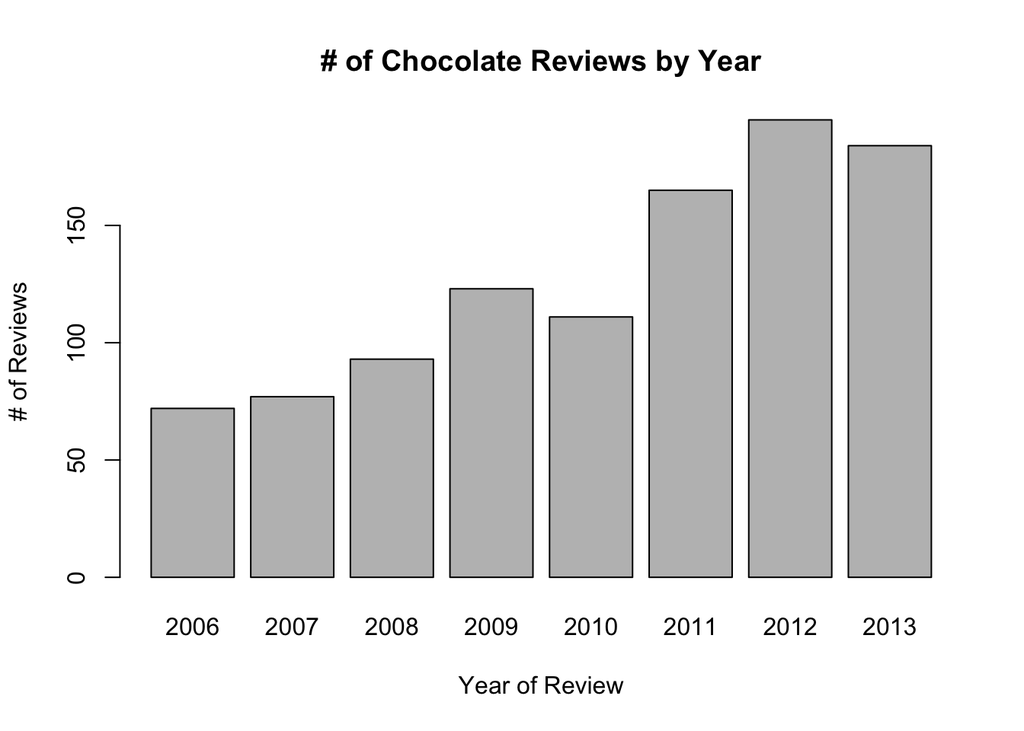

To answer this question we sorted the dataset by the review date, then get the sum of the number of reviews in each year, named them accordingly, & presented it in a bar chart as seen above. You can see that there was steady growth in the number of reviews per year except for in two years of decline that occured in 2010 & 2013.

# Question 3: How do ratings compare across different company locations? Focus on the three locations with the most ratings.

```r
head(choco)
```

```
##    Company Specific.Bean.Origin  REF Review.Date Cocoa.Pct
## 1 A. Morin          Agua Grande 1876        2016        63
## 2 A. Morin                Kpime 1676        2015        70
## 3 A. Morin               Panama 1011        2013        70
## 4 A. Morin           Madagascar 1011        2013        70
## 5 A. Morin               Brazil 1011        2013        70
## 6 A. Morin             Equateur 1011        2013        70
##   Company.Location Rating Bean.Type Broad.Bean.Origin
## 1           France   3.75                    Sao Tome
## 2           France   2.75                        Togo
## 3           France   2.75                      Panama
## 4           France   3.00   Criollo        Madagascar
## 5           France   3.25                      Brazil
## 6           France   3.75                     Ecuador
```

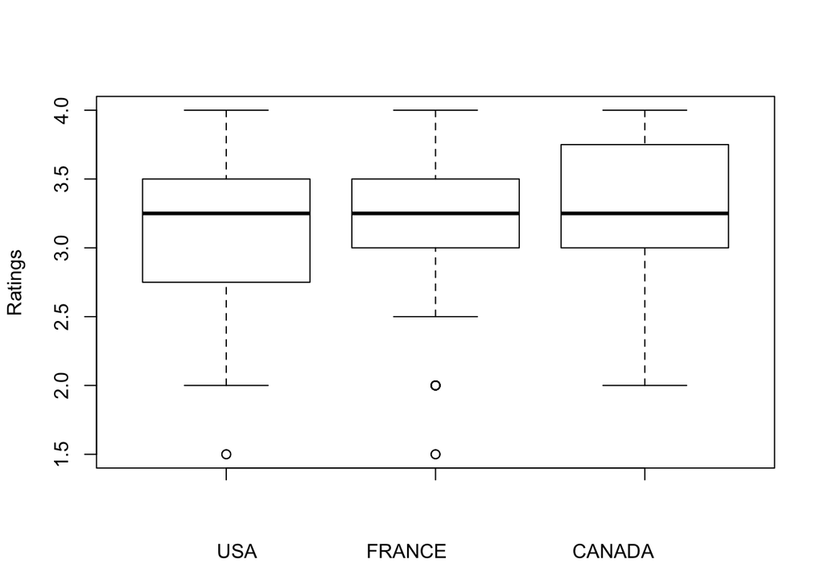

```r
usa <- choco[choco$Company.Location == "U.S.A.",]
france <- choco[choco$Company.Location == "France",]
canada <- choco[choco$Company.Location == "Canada",]
boxplot(usa$Rating, france$Rating, canada$Rating, xlab = "USA                    FRANCE                       CANADA", ylab = "Ratings" )
```

# Question 4 and 5: Is there a correlation between choco percentage in the top locations? Did a particular country have a standard of choco contant?

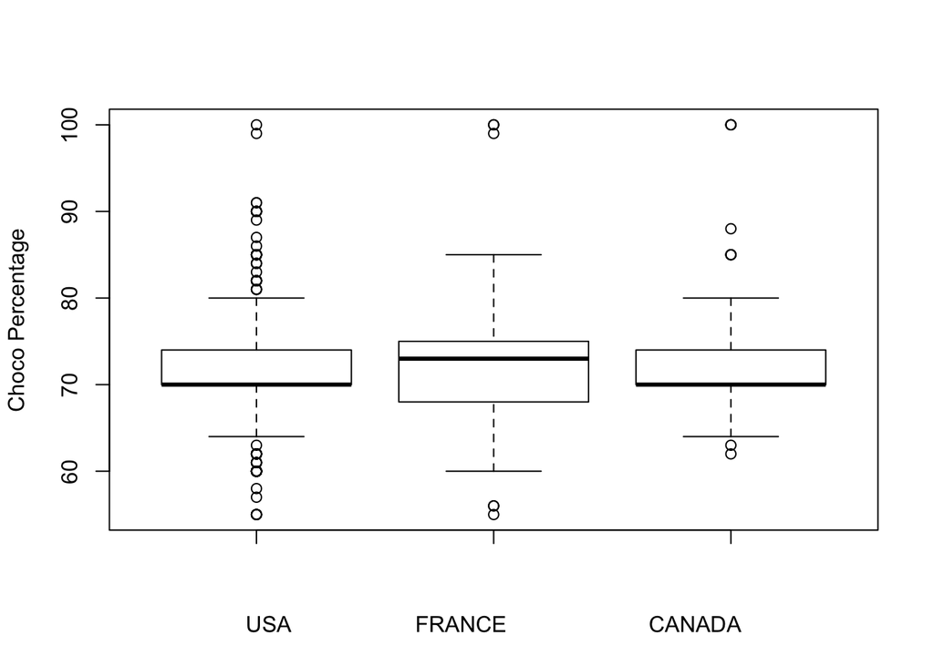

```r
usa <- choco[choco$Company.Location == "U.S.A.",]
france <- choco[choco$Company.Location == "France",]
canada <- choco[choco$Company.Location == "Canada",]

boxplot(usa$Cocoa.Pct,france$Cocoa.Pct,canada$Cocoa.Pct,xlab = "USA                    FRANCE                       CANADA", ylab = "Choco Percentage")
```

For this question we created another boxplot to compare the chocolate percentages so we can determine if there is a range of chocolate used in the candy. From the graph, you can see that the chocolate percentage us usually around 70%. We can also see that there is no standard of chocolate percentage used since the range is between around 60 and 100 in all of the top countries.